# Iterated Filtering 2 Pseudocode and Example

Aaron A. King and Edward Ionides

[Licensed under the Creative Commons Attribution-NonCommercial license](http://creativecommons.org/licenses/by-nc/4.0/). Please share and remix noncommercially, mentioning its origin.

This document was produced using **pomp** version 4.2.2.0.

Iterated filtering is a technique for maximizing the likelihood obtained by filtering. In **pomp**, it is the particle filter that is iterated. The iterated filtering of E. L. Ionides, Bretó, and King (2006) is implemented in the `mif` function. Edward L. Ionides, Nguyen, Atchadé, Stoev, and King (2015) describe an improvement on the original (E. L. Ionides et al. 2006) algorithm. This "IF2" algorithm is implemented in the `mif2` function.

## IF2 algorithm pseudocode

**model input**: Simulators for $f_{X_0}(x_0;\theta)$ and $f_{X_n|X_{n-1}}(x_n| x_{n-1}; \theta)$; evaluator for $f_{Y_n|X_n}(y_n| x_n;\theta)$; data, $y^*_{1:N}$

**algorithmic parameters**: Number of iterations, $M$; number of particles, $J$; initial parameter swarm, $\{\Theta^0_j, j=1,\dots,J\}$; perturbation density, $h_n(\theta|\varphi;\sigma)$; perturbation scale, $\sigma_{1{:}M}$

**output**: Final parameter swarm, $\{\Theta^M_j, j=1,\dots,J\}$

1. $\quad$ For $m$ in $1{:} M$
2. $\quad\quad\quad$ $\Theta^{F,m}_{0,j}\sim h_0(\theta|\Theta^{m-1}_{j}; \sigma_m)$ for $j$ in $1{:} J$
3. $\quad\quad\quad$ $X_{0,j}^{F,m}\sim f_{X_0}(x_0 ; \Theta^{F,m}_{0,j})$ for $j$ in $1{:} J$
4. $\quad\quad\quad$ For $n$ in $1{:} N$
5. $\quad\quad\quad\quad\quad$ $\Theta^{P,m}_{n,j}\sim h_n(\theta|\Theta^{F,m}_{n-1,j},\sigma_m)$ for $j$ in $1{:} J$
6. $\quad\quad\quad\quad\quad$ $X_{n,j}^{P,m}\sim f_{X_n|X_{n-1}}(x_n | X^{F,m}_{n-1,j}; \Theta^{P,m}_{n,j})$ for $j$ in $1{:} J$
7. $\quad\quad\quad\quad\quad$ $w_{n,j}^m = f_{Y_n|X_n}(y^*_n| X_{n,j}^{P,m} ; \Theta^{P,m}_{n,j})$ for $j$ in $1{:} J$
8. $\quad\quad\quad\quad\quad$ Draw $k_{1{:}J}$ with $P[k_j=i]= w_{n,i}^m\Big/\sum_{u=1}^J w_{n,u}^m$
9. $\quad\quad\quad\quad\quad$ $\Theta^{F,m}_{n,j}=\Theta^{P,m}_{n,k_j}$ and $X^{F,m}_{n,j}=X^{P,m}_{n,k_j}$ for $j$ in $1{:} J$
10. $\quad\quad\quad$ End For
11. $\quad\quad\quad$ Set $\Theta^{m}_{j}=\Theta^{F,m}_{N,j}$ for $j$ in $1{:} J$
12. $\quad$ End For

## An example

The following constructs the Gompertz example that is provided with **pomp** (see `?gompertz`) and extracts the parameters at which the data were generated. It is meant to be directly comparable with the example displayed in the King, Nguyen, and Ionides (2016) [*J. Stat. Softw.* paper](https://kingaa.github.io/pomp/vignettes/pompjss.pdf).

```r
library(pomp)
gompertz() -> gomp
theta <- coef(gomp)
theta.true <- theta
```

Let's use IF2 to obtain an approximate MLE for these data. We'll initialize the algorithm at several starting points around `theta.true` and just estimate the parameters $r$, $\tau$, and $\sigma$:

```r
library(foreach)
library(doParallel)
registerDoParallel()

estpars <- c("r","sigma","tau")
```

```r
library(doRNG)
registerDoRNG(525386942)

foreach(i=1:10,.inorder=FALSE) %dopar% {
  theta.guess <- theta.true
  theta.guess[estpars] <- rlnorm(
    n=length(estpars),
    meanlog=log(theta.guess[estpars]),
    sdlog=1
  )
  gomp |>
    mif2(
      Nmif=50,
      params=theta.guess,
      rw.sd=rw.sd(r=0.02,sigma=0.02,tau=0.05),
      cooling.fraction.50=0.95,
      Np=2000
    ) |>
    continue(Nmif=50,cooling.fraction=0.8) |>
    continue(Nmif=50,cooling.fraction=0.6) |>
    continue(Nmif=50,cooling.fraction=0.2) -> m1
  ll <- replicate(n=10,logLik(pfilter(m1,Np=10000)))
  list(mif=m1,ll=logmeanexp(ll,se=TRUE))
} -> mf
```

```r
lls <- sapply(mf,getElement,"ll")
best <- which.max(sapply(mf,getElement,"ll")[1,])
theta.mif <- coef(mf[[best]]$mif)

replicate(10,logLik(pfilter(gomp,params=theta.mif,Np=10000))) |>
  logmeanexp(se=TRUE) -> pf.loglik.mif
```

Note that `gompertz()` uses parameter transformations to ensure that the search for the MLE is constrained to positive parameters. See the **pomp** documentation (`?pomp`) and the section on Parameter Transformations in the [Getting Started vignette](https://kingaa.github.io/pomp/vignettes/getting_started.html)).

Each of the 10 `mif2` runs ends up at a different point estimate. We focus on that with the highest estimated likelihood, having evaluated the likelihood several times to reduce the Monte Carlo error in the likelihood evaluation. The particle filter produces an unbiased estimate of the likelihood; therefore, we will average the likelihoods, not the log likelihoods.

Convergence plots can be used to help diagnose convergence of the iterated filtering algorithm. Something like the following can be obtained by executing `plot(mf)`.

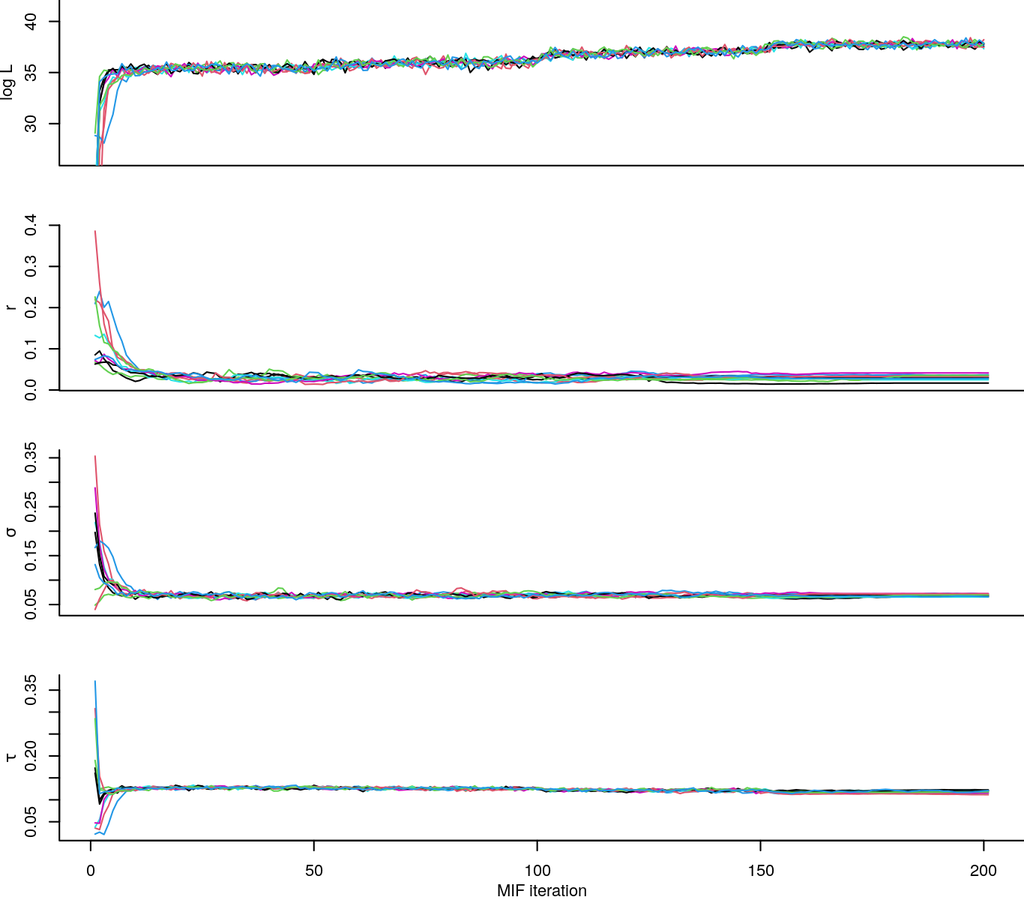

Here is a summary of the results:

|  | r | sigma | tau | $\hat{\ell}$ | s.e. $\hat{\ell}$ | $\ell$ |
| --- | --- | --- | --- | --- | --- | --- |
| Truth | 0.1000 | 0.1000 | 0.1000 | 35.99 | 0.04 | 36.01 |
| Exact MLE | 0.0322 | 0.0694 | 0.1168 | 37.87 | 0.03 | 37.88 |
| IF2 MLE | 0.0372 | 0.0706 | 0.1153 | 37.86 | 0.03 | 37.86 |

Compare this with the [performance of IF1 (`mif`) on the same task](https://kingaa.github.io/pomp/vignettes/pompjss.pdf#page=20).

The fact that the likelihood, $\ell$, at the IF2 MLE is higher than it is at the truth is evidence that this parameter is actually close to the true MLE.

## Links

[**pomp** homepage](https://kingaa.github.io/pomp/)  
[**R** codes for this document](https://raw.githubusercontent.com/kingaa/pomp/gh-pages/vignettes/mif2.R)

## References

Ionides EL, Bretó C, King AA (2006). “Inference for Nonlinear Dynamical Systems.” *Proceedings of the National Academy of Sciences of the U.s.a.*, **103**(49), 18438–18443. https://doi.org/10.1073/pnas.0603181103.

Ionides EL, Nguyen D, Atchadé Y, Stoev S, King AA (2015). “Inference for Dynamic and Latent Variable Models via Iterated, Perturbed Bayes Maps.” *Proceedings of the National Academy of Sciences of the U.s.a.*, **112**(3), 719–724. https://doi.org/10.1073/pnas.1410597112.

King AA, Nguyen D, Ionides EL (2016). “Statistical Inference for Partially Observed Markov Processes via the R Package Pomp.” *Journal of Statistical Software*, **69**(12), 1–43. https://doi.org/10.18637/jss.v069.i12.